# R Notebook

# Data Preparation

```r
library(arrow)
library(MASS)
library(tidyverse)
library(sf)
library(leaps)
library(lme4)


data <- read_parquet("data_processed/NZ_FR_IAR_final_dataset.parquet")

data <- data |>
  drop_na(
    reported_mmi,
    Rhypo_km,
    mt_Mw,
    Vs30_raw,
    event_depth_km,
    publicid
  )


# filters the dataset to the decided upon report count
data_sd <- data |>
  filter(report_count >= 4)

data_re <- data |>
  filter(report_count >= 5)
```

# Checking Vs30 data as no model wants to use it

Uses a Box-Cox transformation to find the most suitable transformation of `felt_mmi_median_cells` for only Vs30.

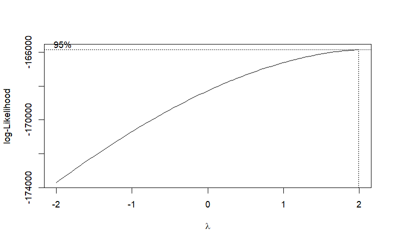

```r
bc <- boxcox(
  lm(felt_mmi_median_cells ~ Vs30_raw, data = data_sd)
)
```

```r
best_lambda <- bc$x[which.max(bc$y)]

best_lambda
```

```
[1] 2
```

# Box-Cox Model

Applies the selected Box-Cox transformation using x^2 and fits a linear model using `Vs30_raw` as the predictor.

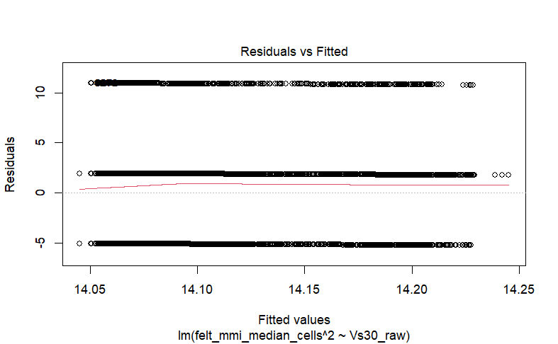

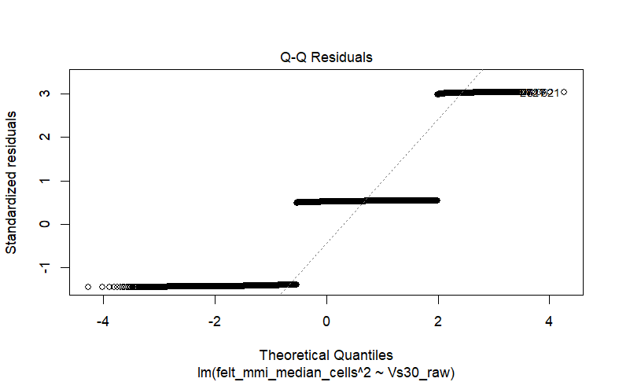

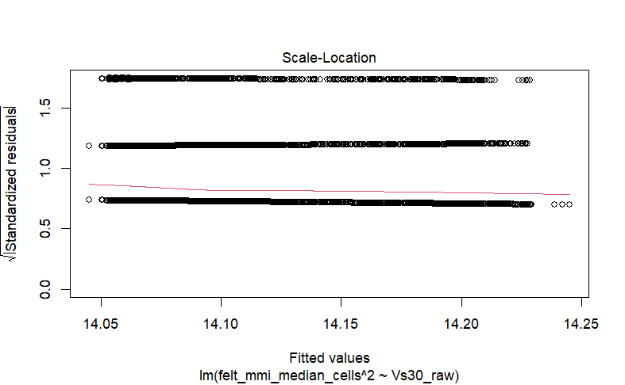

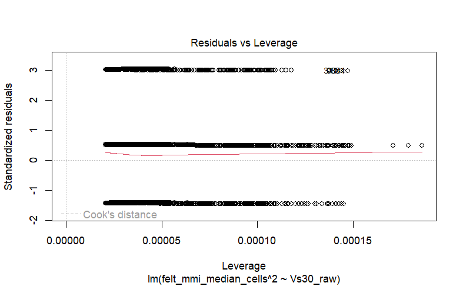

```r
model_bc <- lm(felt_mmi_median_cells^2 ~ Vs30_raw, data = data_sd)

plot(model_bc)
```

```r
summary(model_bc)
```

```
Call:
lm(formula = felt_mmi_median_cells^2 ~ Vs30_raw, data = data_sd)

Residuals:
   Min     1Q Median     3Q    Max
-5.228 -5.068  1.875  1.909 10.950

Coefficients:
             Estimate Std. Error t value Pr(>|t|)
(Intercept) 1.400e+01  4.118e-02 340.060  < 2e-16 ***
Vs30_raw    2.860e-04  1.001e-04   2.856  0.00429 **
---
Signif. codes:  0 ‘***’ 0.001 ‘**’ 0.01 ‘*’ 0.05 ‘.’ 0.1 ‘ ’ 1

Residual standard error: 3.605 on 49075 degrees of freedom
Multiple R-squared:  0.0001662, Adjusted R-squared:  0.0001458
F-statistic: 8.156 on 1 and 49075 DF,  p-value: 0.004293
```

# Best Subset Selection

Uses best subset selection to compare combinations of earthquake depth, hypocentral distance, moment magnitude and Vs30 for predicting the Median MMI.

```r
model_lr_rss <- regsubsets(
  felt_mmi_median_cells ~ event_depth_km + Rhypo_km + Vs30_raw + mt_Mw,
  data = data_sd,
  nvmax = 4
)

summary(model_lr_rss)
```

```
Subset selection object
Call: regsubsets.formula(felt_mmi_median_cells ~ event_depth_km + Rhypo_km +
    Vs30_raw + mt_Mw, data = data_sd, nvmax = 4)
4 Variables  (and intercept)
               Forced in Forced out
event_depth_km     FALSE      FALSE
Rhypo_km           FALSE      FALSE
Vs30_raw           FALSE      FALSE
mt_Mw              FALSE      FALSE
1 subsets of each size up to 4
Selection Algorithm: exhaustive
         event_depth_km Rhypo_km Vs30_raw mt_Mw
1  ( 1 ) " "            " "      " "      "*"
2  ( 1 ) " "            "*"      " "      "*"
3  ( 1 ) " "            "*"      "*"      "*"
4  ( 1 ) "*"            "*"      "*"      "*"
```

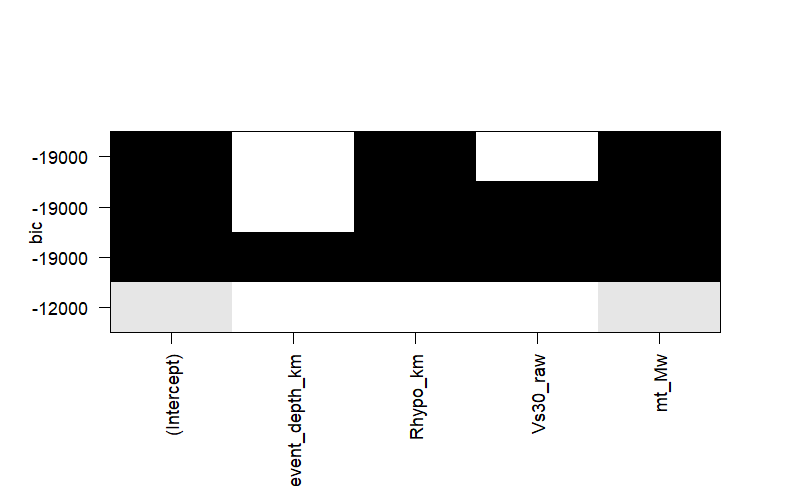

```r
plot(model_lr_rss)
```

```r
summary(model_lr_rss)$bic
```

```
[1] -11505.24 -19229.30 -19224.91 -19214.44
```

# Filtering Felt Reports

With the selected variables applies a Box-Cox analysis to determine the most suitable transformation for the filtered data.

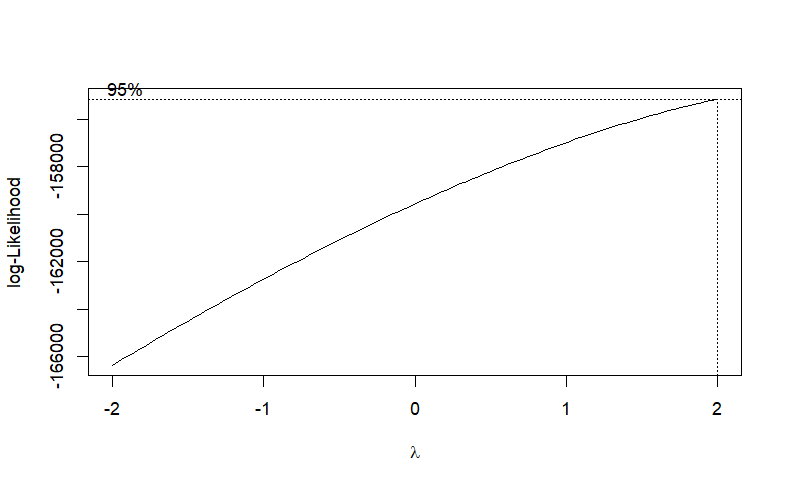

```r
model_lr_bc <- boxcox(
  lm(felt_mmi_median_cells ~ Rhypo_km +mt_Mw, data = data_sd)
)
```

```r
best_lambda <- model_lr_bc$x[which.max(model_lr_bc$y)]
best_lambda
```

```
[1] 2
```

# Selected Linear Model — Full Dataset

Fits the model selected from the best subset analysis and boxcox transformations and checks its model summary and diagnostic plots.

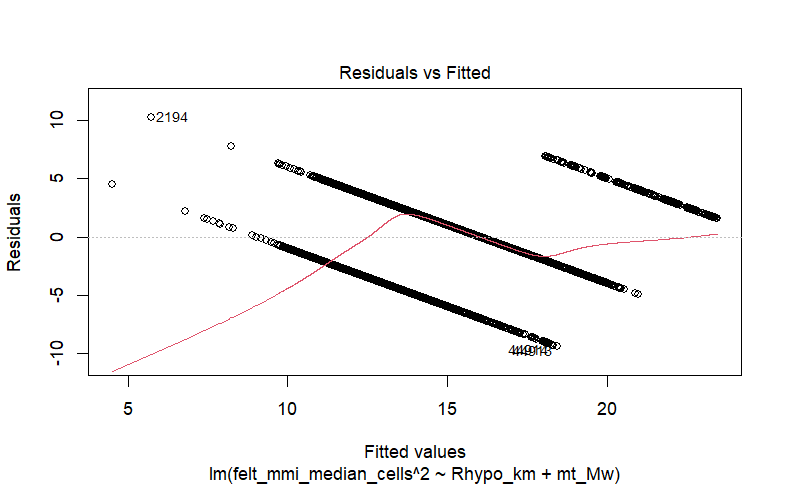

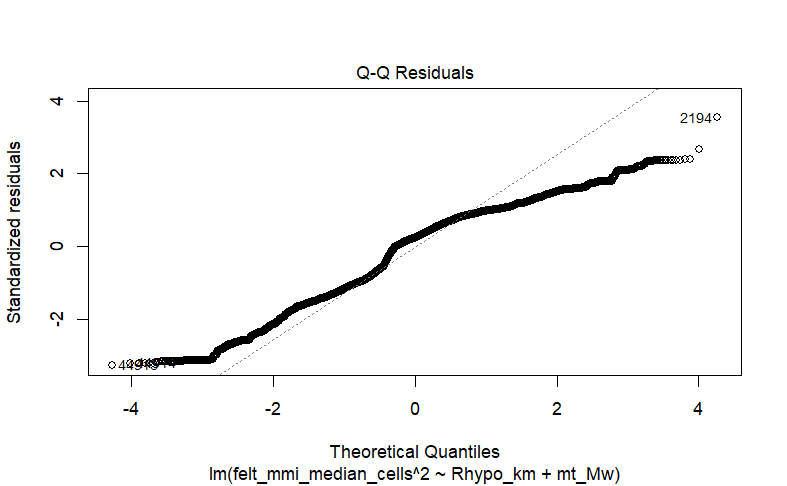

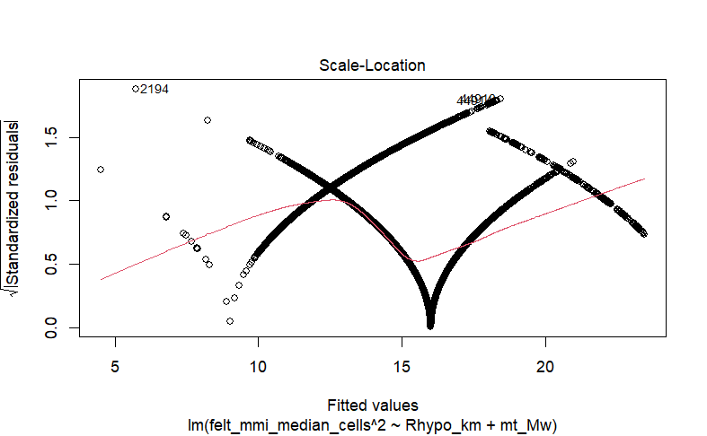

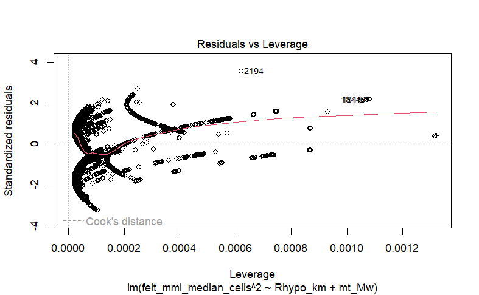

```r
model_lr <- lm(
  felt_mmi_median_cells^2 ~ Rhypo_km + mt_Mw,
  data = data_sd
  )

plot(model_lr)
```

```r
summary(model_lr)
```

```
Call:
lm(formula = felt_mmi_median_cells^2 ~ Rhypo_km + mt_Mw, data = data_sd)

Residuals:
    Min      1Q  Median      3Q     Max
-9.4359 -2.5555  0.6967  2.4147 10.2757

Coefficients:
              Estimate Std. Error t value Pr(>|t|)
(Intercept) -2.820e+00  1.052e-01  -26.80   <2e-16 ***
Rhypo_km    -8.962e-03  9.302e-05  -96.34   <2e-16 ***
mt_Mw        3.451e+00  2.109e-02  163.66   <2e-16 ***
---
Signif. codes:  0 ‘***’ 0.001 ‘**’ 0.01 ‘*’ 0.05 ‘.’ 0.1 ‘ ’ 1

Residual standard error: 2.9 on 49074 degrees of freedom
Multiple R-squared:  0.3531,    Adjusted R-squared:  0.3531
F-statistic: 1.339e+04 on 2 and 49074 DF,  p-value: < 2.2e-16
```

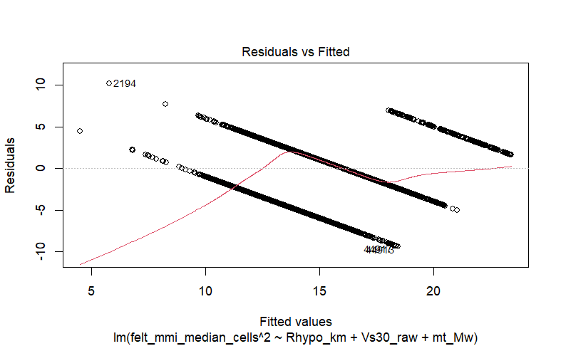

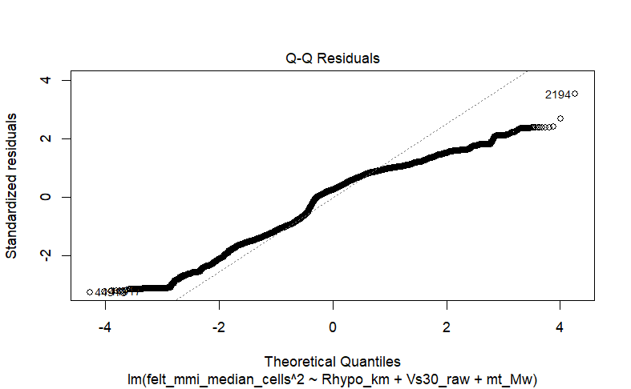

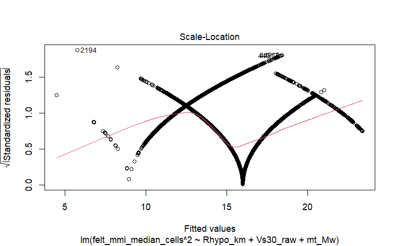

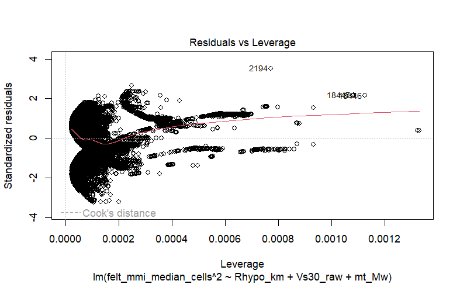

```r
model_lr_2 <- lm(
  felt_mmi_median_cells^2 ~ Rhypo_km + Vs30_raw + mt_Mw,
  data = data_sd
  )

plot(model_lr_2)
```

```r
summary(model_lr_2)
```

```
Call:
lm(formula = felt_mmi_median_cells^2 ~ Rhypo_km + Vs30_raw +
    mt_Mw, data = data_sd)

Residuals:
    Min      1Q  Median      3Q     Max
-9.4403 -2.5546  0.6893  2.4052 10.1974

Coefficients:
              Estimate Std. Error t value Pr(>|t|)
(Intercept) -2.888e+00  1.097e-01  -26.34   <2e-16 ***
Rhypo_km    -8.947e-03  9.324e-05  -95.96   <2e-16 ***
Vs30_raw     1.770e-04  8.082e-05    2.19   0.0285 *
mt_Mw        3.451e+00  2.109e-02  163.64   <2e-16 ***
---
Signif. codes:  0 ‘***’ 0.001 ‘**’ 0.01 ‘*’ 0.05 ‘.’ 0.1 ‘ ’ 1

Residual standard error: 2.9 on 49073 degrees of freedom
Multiple R-squared:  0.3532,    Adjusted R-squared:  0.3531
F-statistic:  8932 on 3 and 49073 DF,  p-value: < 2.2e-16
```

# Mixed-Effects Model

Fits a linear mixed-effects model with earthquake ID (`publicid`) as a random effect to account for multiple observations coming from the same earthquake. still very Work in progress

```r
model_mem_1 <- lmer(
  log(reported_mmi) ~ Rhypo_km + (1 | publicid), data = data_re,
  REML = FALSE
  )
summary(model_mem_1)
```

```
Linear mixed model fit by maximum likelihood  ['lmerMod']
Formula: log(reported_mmi) ~ Rhypo_km + (1 | publicid)
   Data: data_re

      AIC       BIC    logLik -2*log(L)  df.resid
 -54483.7  -54448.5   27245.9  -54491.7     49073

Scaled residuals:
    Min      1Q  Median      3Q     Max
-4.3072 -0.6796  0.0993  0.6786  7.2979

Random effects:
 Groups   Name        Variance Std.Dev.
 publicid (Intercept) 0.01650  0.1284
 Residual             0.01902  0.1379
Number of obs: 49077, groups:  publicid, 158

Fixed effects:
              Estimate Std. Error t value
(Intercept)  1.394e+00  1.072e-02  130.04
Rhypo_km    -6.860e-04  7.485e-06  -91.64

Correlation of Fixed Effects:
         (Intr)
Rhypo_km -0.137
```

```r
cat("\n")
```

```r
model_mem_2 <- lmer(
  log(reported_mmi) ~ Rhypo_km + mt_Mw + (1 | publicid), data = data_re,
  REML = FALSE
  )
summary(model_mem_2)
```

```
Linear mixed model fit by maximum likelihood  ['lmerMod']
Formula: log(reported_mmi) ~ Rhypo_km + mt_Mw + (1 | publicid)
   Data: data_re

      AIC       BIC    logLik -2*log(L)  df.resid
 -54549.9  -54505.9   27279.9  -54559.9     49072

Scaled residuals:
    Min      1Q  Median      3Q     Max
-4.3101 -0.6812  0.0996  0.6788  7.7252

Random effects:
 Groups   Name        Variance Std.Dev.
 publicid (Intercept) 0.009482 0.09738
 Residual             0.019026 0.13793
Number of obs: 49077, groups:  publicid, 158

Fixed effects:
              Estimate Std. Error t value
(Intercept)  7.395e-01  6.905e-02  10.710
Rhypo_km    -6.868e-04  7.476e-06 -91.871
mt_Mw        1.261e-01  1.322e-02   9.541

Correlation of Fixed Effects:
         (Intr) Rhyp_k
Rhypo_km  0.061
mt_Mw    -0.993 -0.082
```

```r
cat("\n")
```

```r
model_mem_3 <- lmer(
  log(reported_mmi) ~ Rhypo_km + mt_Mw + Vs30_raw + (1 | publicid), data = data_re,
  REML = FALSE
  )
summary(model_mem_3)
```

```
Linear mixed model fit by maximum likelihood  ['lmerMod']
Formula: log(reported_mmi) ~ Rhypo_km + mt_Mw + Vs30_raw + (1 | publicid)
   Data: data_re

      AIC       BIC    logLik -2*log(L)  df.resid
 -54549.8  -54497.0   27280.9  -54561.8     49071

Scaled residuals:
    Min      1Q  Median      3Q     Max
-4.3023 -0.6804  0.0995  0.6760  7.7089

Random effects:
 Groups   Name        Variance Std.Dev.
 publicid (Intercept) 0.009448 0.0972
 Residual             0.019025 0.1379
Number of obs: 49077, groups:  publicid, 158

Fixed effects:
              Estimate Std. Error t value
(Intercept)  7.379e-01  6.894e-02  10.704
Rhypo_km    -6.860e-04  7.502e-06 -91.437
mt_Mw        1.260e-01  1.320e-02   9.550
Vs30_raw     5.517e-06  3.986e-06   1.384

Correlation of Fixed Effects:
         (Intr) Rhyp_k mt_Mw
Rhypo_km  0.059
mt_Mw    -0.992 -0.083
Vs30_raw -0.017  0.083 -0.006
```

```r
cat("\n")
```

```r
model_mem_4 <- lmer(
  log(reported_mmi) ~ Rhypo_km + mt_Mw + Vs30_raw + event_depth_km + (1 | publicid), data = data_re,
  REML = FALSE
  )
summary(model_mem_4)
```

```
Linear mixed model fit by maximum likelihood  ['lmerMod']
Formula: log(reported_mmi) ~ Rhypo_km + mt_Mw + Vs30_raw + event_depth_km +      (1 | publicid)
   Data: data_re

      AIC       BIC    logLik -2*log(L)  df.resid
 -54558.1  -54496.5   27286.0  -54572.1     49070

Scaled residuals:
    Min      1Q  Median      3Q     Max
-4.3036 -0.6806  0.0996  0.6755  7.7451

Random effects:
 Groups   Name        Variance Std.Dev.
 publicid (Intercept) 0.008737 0.09347
 Residual             0.019026 0.13793
Number of obs: 49077, groups:  publicid, 158

Fixed effects:
                 Estimate Std. Error t value
(Intercept)     7.228e-01  6.655e-02  10.860
Rhypo_km       -6.872e-04  7.514e-06 -91.446
mt_Mw           1.251e-01  1.272e-02   9.840
Vs30_raw        5.512e-06  3.986e-06   1.383
event_depth_km  4.403e-04  1.349e-04   3.265

Correlation of Fixed Effects:
            (Intr) Rhyp_k mt_Mw  Vs30_r
Rhypo_km     0.066
mt_Mw       -0.988 -0.084
Vs30_raw    -0.017  0.083 -0.006
evnt_dpth_k -0.067 -0.067 -0.024 -0.004
```

```r
cat("\n")
```

```r
anova(model_mem_1, model_mem_2, model_mem_3, model_mem_4)
```

```
Data: data_re
Models:
model_mem_1: log(reported_mmi) ~ Rhypo_km + (1 | publicid)
model_mem_2: log(reported_mmi) ~ Rhypo_km + mt_Mw + (1 | publicid)
model_mem_3: log(reported_mmi) ~ Rhypo_km + mt_Mw + Vs30_raw + (1 | publicid)
model_mem_4: log(reported_mmi) ~ Rhypo_km + mt_Mw + Vs30_raw + event_depth_km + (1 | publicid)
            npar    AIC    BIC logLik -2*log(L)   Chisq Df Pr(>Chisq)
model_mem_1    4 -54484 -54449  27246    -54492
model_mem_2    5 -54550 -54506  27280    -54560 68.1537  1    < 2e-16 ***
model_mem_3    6 -54550 -54497  27281    -54562  1.9145  1    0.16647
model_mem_4    7 -54558 -54496  27286    -54572 10.3140  1    0.00132 **
---
Signif. codes:  0 ‘***’ 0.001 ‘**’ 0.01 ‘*’ 0.05 ‘.’ 0.1 ‘ ’ 1
```

```r
model_mem_5 <- lmer(
  log(reported_mmi) ~ Rhypo_km + mt_Mw + event_depth_km + (1 | publicid), data = data_re,
  REML = FALSE
  )
summary(model_mem_5)
```

```
Linear mixed model fit by maximum likelihood  ['lmerMod']
Formula: log(reported_mmi) ~ Rhypo_km + mt_Mw + event_depth_km + (1 |      publicid)
   Data: data_re

      AIC       BIC    logLik -2*log(L)  df.resid
 -54558.2  -54505.4   27285.1  -54570.2     49071

Scaled residuals:
    Min      1Q  Median      3Q     Max
-4.3114 -0.6819  0.1000  0.6781  7.7614

Random effects:
 Groups   Name        Variance Std.Dev.
 publicid (Intercept) 0.008769 0.09364
 Residual             0.019026 0.13794
Number of obs: 49077, groups:  publicid, 158

Fixed effects:
                 Estimate Std. Error t value
(Intercept)     7.244e-01  6.666e-02  10.867
Rhypo_km       -6.880e-04  7.488e-06 -91.879
mt_Mw           1.252e-01  1.274e-02   9.831
event_depth_km  4.411e-04  1.351e-04   3.265

Correlation of Fixed Effects:
            (Intr) Rhyp_k mt_Mw
Rhypo_km     0.067
mt_Mw       -0.989 -0.084
evnt_dpth_k -0.067 -0.067 -0.024
```

```r
cat("\n")
```

```r
anova(model_mem_2, model_mem_5)
```

```
Data: data_re
Models:
model_mem_2: log(reported_mmi) ~ Rhypo_km + mt_Mw + (1 | publicid)
model_mem_5: log(reported_mmi) ~ Rhypo_km + mt_Mw + event_depth_km + (1 | publicid)
            npar    AIC    BIC logLik -2*log(L)  Chisq Df Pr(>Chisq)
model_mem_2    5 -54550 -54506  27280    -54560
model_mem_5    6 -54558 -54505  27285    -54570 10.317  1   0.001318 **
---
Signif. codes:  0 ‘***’ 0.001 ‘**’ 0.01 ‘*’ 0.05 ‘.’ 0.1 ‘ ’ 1
```

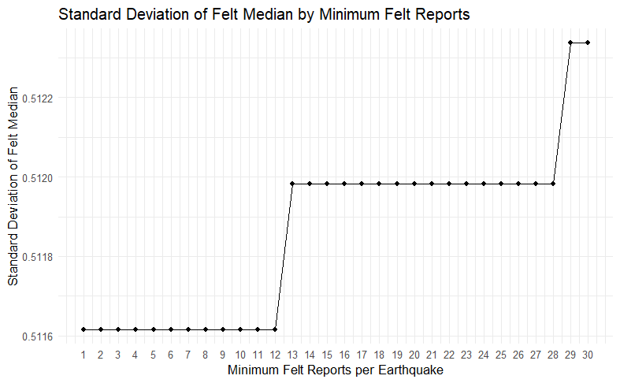

```r
library(tidyverse)

sd_by_min_reports <- map_dfr(1:30, function(min_reports) {

  filtered <- data_sd |>
    filter(felt_report_count >= min_reports) |>
    distinct(publicid, felt_mmi_median_cells)

  tibble(
    min_felt_reports = min_reports,
    sd_felt_median = sd(filtered$felt_mmi_median_cells, na.rm = TRUE),
    n_earthquakes = sum(!is.na(filtered$felt_mmi_median_cells))
  )
})

ggplot(
  sd_by_min_reports,
  aes(x = min_felt_reports, y = sd_felt_median)
) +
  geom_line() +
  geom_point() +
  scale_x_continuous(breaks = 1:30) +
  theme_minimal() +
  labs(
    x = "Minimum Felt Reports per Earthquake",
    y = "Standard Deviation of Felt Median",
    title = "Standard Deviation of Felt Median by Minimum Felt Reports"
  )
```

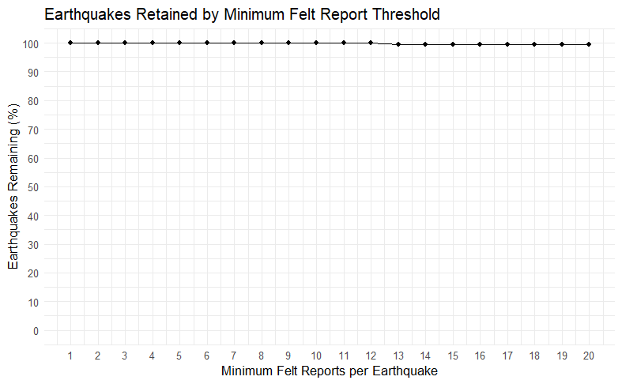

```r
earthquakes <- data_re |>
  distinct(publicid, felt_report_count)

total_earthquakes <- nrow(earthquakes)

earthquakes_remaining <- map_dfr(1:20, function(min_reports) {

  filtered <- earthquakes |>
    filter(felt_report_count >= min_reports)

  tibble(
    min_felt_reports = min_reports,
    earthquakes_remaining = nrow(filtered),
    percent_remaining = nrow(filtered) / total_earthquakes * 100
  )
})

ggplot(
  earthquakes_remaining,
  aes(x = min_felt_reports, y = percent_remaining)
) +
  geom_line() +
  geom_point() +
  scale_x_continuous(breaks = 1:20) +
  scale_y_continuous(
    limits = c(0, 100),
    breaks = seq(0, 100, 10)
  ) +
  theme_minimal() +
  labs(
    x = "Minimum Felt Reports per Earthquake",
    y = "Earthquakes Remaining (%)",
    title = "Earthquakes Retained by Minimum Felt Report Threshold"
  )
```